# Trabalho R - Análise do saneamento e desenvolvimento social brasileiro

Gustavo Masashi Tiba Hoshima

Este trabalho foi feito utilizando os dados do Sistema Nacional de Informações sobre Saneamento(SNIS) obtido da Bases dos Dados e do Atlas do Desenvolvimento Humano.

Links: SNIS - https://basedosdados.org/dataset/2a543ad8-3cdb-4047-9498-efe7fb8ed697?table=df7cf198-4889-4baf-bb77-4e0e28eb90ca Atlas - http://www.atlasbrasil.org.br

```r
#Versão do R: 4.4.2

#Serão usadas as seguintes bibliotecas:readr,readxl,dplyr,janitor,ggplot2,scales,ggrepel,geobr,sf
#Para renderizar o código em html clique em knit e 'Knit to HTML'

#Substitua o caminho do arquivo nas seguintes variáveis caso queira rodar o código localmente
arq_snis  <- 'C:\\Users\\Desk-Top\\Downloads\\br_mdr_snis_municipio_agua_esgoto.csv'
arq_extra <- 'C:\\Users\\Desk-Top\\Downloads\\data.xlsx'
```

```r
#Carregando as bibliotecas usadas
library(readr)
library(readxl)
library(dplyr)
library(janitor)
library(ggplot2)
library(scales)
library(ggrepel)
library(geobr)
library(sf)
```

```r
#Carregando os dados do CSV para o R
snis <- readr::read_csv(arq_snis, show_col_types = FALSE) |>
  janitor::clean_names()

snis <- readr::read_csv(arq_snis, show_col_types = FALSE) |>
  janitor::clean_names()

aba1  <- readxl::excel_sheets(arq_extra)[1]
extra <- readxl::read_excel(arq_extra, sheet = aba1) |>
  janitor::clean_names()

#Filtrando só para os anos de 2020 e 2021
anos_alvo <- c(2020, 2021)
snis_20_21 <- snis |>
  dplyr::filter(.data[['ano']] %in% anos_alvo)
```

```r
#Funções criadas pelo ChatGPT para a filtragem dos DF
pega_col <- function(df, candidatas) {
  hit <- intersect(candidatas, names(df))
  if (length(hit) == 0) NA_character_ else hit[[1]]
}
normaliza_id_mun <- function(x){
  x <- as.character(x)
  x <- stringr::str_replace_all(x, "\\D", "")
  stringr::str_pad(x, 7, "left", "0")
}
pega_ano <- function(df) pega_col(df, c("ano","year","exercicio","competencia"))
pega_id  <- function(df) pega_col(df, c("id_municipio","id_municipio_ibge","cod_municipio","codigo_municipio","id_municipio_7"))
```

```r
#Removendo as últimas 3 lihas (São apenas linhas com NA )
extra <- extra %>% slice(1:(n() - 3))


#Removendo colunas desnecessárias
cols_para_excluir <- c("id_municipio",'quantidade_sede_municipal_agua','quantidade_sede_municipal_esgoto','quantidade_localidade_agua',
                       'quantidade_localidade_esgoto','volume_agua_bruta_exportado','volume_agua_tratada_importado',
                       'volume_agua_tratada_exportado','volume_esgoto_bruto_exportado','volume_esgoto_bruto_importado','volume_esgoto_importado',
                       'volume_esgoto_bruto_exportado_tratamento_importador')

snis_20_21_col <- snis_20_21 %>%
  select(-any_of(cols_para_excluir))

#Filtrando o Data Frame por ano
snis_2020 <- snis_20_21_col %>% filter(.data[['ano']] == 2020)
snis_2021 <- snis_20_21_col %>% filter(.data[['ano']] == 2021)
```

```r
#Redefinindo nomes para facilitar
df <- snis_2020
df2 <- snis_2021


# identifica colunas (utilizei o ChatGPT para criar essas funções)
idx_cols <- names(df)[startsWith(names(df), "indice")]
num_cols <- names(df)[sapply(df, is.numeric)]
sum_cols <- setdiff(num_cols, c(idx_cols, "sigla_uf"))

idx_cols2 <- names(df2)[startsWith(names(df2), "indice")]
num_cols2 <- names(df2)[sapply(df, is.numeric)]
sum_cols2 <- setdiff(num_cols2, c(idx_cols2, "sigla_uf"))

# Agrega por UF
res_por_uf <- df %>%
  group_by(sigla_uf) %>%
  summarise(
    across(all_of(sum_cols),  ~ sum(.x,  na.rm = TRUE)),
    across(all_of(idx_cols),  ~ mean(.x, na.rm = TRUE)),
    .groups = "drop"
  )

res_por_uf2 <- df2 %>%
  group_by(sigla_uf) %>%
  summarise(
    across(all_of(sum_cols2),  ~ sum(.x,  na.rm = TRUE)),
    across(all_of(idx_cols2),  ~ mean(.x, na.rm = TRUE)),
    .groups = "drop"
  )

#Removendo a coluna de anos já todos os dados de cada dataframe são referentes ao mesmo ano
sn_2020 <- res_por_uf %>% select(-ano)
sn_2021 <- res_por_uf2 %>% select(-ano)

#ChatGPT - usei para criar uma função que agregue todos os estados e crie uma linha do Brasil
agrega_brasil_snis <- function(df) {
  idx_cols <- names(df)[startsWith(names(df), "indice")]             # médias
  num_cols <- names(df)[vapply(df, is.numeric, logical(1))]          # numéricas
  sum_cols <- setdiff(num_cols, idx_cols)                            # somas

  df %>%
    summarise(
      across(all_of(sum_cols),  ~ sum(.x,  na.rm = TRUE), .names = "{.col}"),
      across(all_of(idx_cols),  ~ mean(.x, na.rm = TRUE), .names = "{.col}")
    ) %>%
    mutate(sigla_uf = "BR") %>%
    relocate(sigla_uf)
}

com_br20 <- agrega_brasil_snis(sn_2020)
com_br21 <- agrega_brasil_snis(sn_2021)

#Adicionando linha do 'BR' ao data-frame
snis2_20 <- bind_rows(sn_2020, com_br20)
snis2_21 <- bind_rows(sn_2021, com_br21)
```

```r
#Utilizei o ChatGPT para criar uma função que trocasse o estado pela sigla de UF para poder agrupar com a outra tabela
padroniza_territorialidades <- function(extra) {
  stopifnot("territorialidades" %in% names(extra))
  if (!requireNamespace("dplyr", quietly = TRUE)) stop("Instale 'dplyr'.")
  if (!requireNamespace("stringr", quietly = TRUE)) stop("Instale 'stringr'.")
  if (!requireNamespace("stringi", quietly = TRUE)) stop("Instale 'stringi'.")

  # mapa nome -> sigla (chave em minúsculas e sem acento)
  mapa_uf <- c(
    "acre"="AC","alagoas"="AL","amapa"="AP","amazonas"="AM","bahia"="BA",
    "ceara"="CE","distrito federal"="DF","espirito santo"="ES","goias"="GO",
    "maranhao"="MA","mato grosso"="MT","mato grosso do sul"="MS","minas gerais"="MG",
    "para"="PA","paraiba"="PB","parana"="PR","pernambuco"="PE","piaui"="PI",
    "rio de janeiro"="RJ","rio grande do norte"="RN","rio grande do sul"="RS",
    "rondonia"="RO","roraima"="RR","santa catarina"="SC","sao paulo"="SP",
    "sergipe"="SE","tocantins"="TO"
  )

  dplyr::mutate(
    extra,
    # normaliza para comparar
    .norm = stringr::str_to_lower(stringi::stri_trans_general(territorialidades, "Latin-ASCII")),
    .norm = stringr::str_trim(.norm),
    territorialidades = dplyr::case_when(
      .norm == "brasil" ~ "BR",
      .norm %in% names(mapa_uf) ~ mapa_uf[.norm],
      # se já vier como sigla (2 letras), mantém em maiúsculas
      nchar(territorialidades) == 2 ~ toupper(territorialidades),
      TRUE ~ territorialidades
    )
  ) |>
    dplyr::select(-.norm)
}

extra <- padroniza_territorialidades(extra)
```

```r
#Uso de ChatGPT - Esta função separa por ano as colunas referentes ao ano de 2020 e 2021
separa_extra_20_21 <- function(extra, id_cols = NULL) {
  # Colunas que NÃO terminam em 2020/2021 (ids, chaves, etc.)
  if (is.null(id_cols)) {
    id_cols <- names(extra)[!grepl("(2020|2021)$", names(extra))]
  }

  cols20 <- c(id_cols, grep("2020$", names(extra), value = TRUE))
  cols21 <- c(id_cols, grep("2021$", names(extra), value = TRUE))

  extra_2020 <- extra %>%
    select(all_of(cols20)) %>%
    rename_with(~ sub("_?2020$", "", .x), ends_with("2020"))

  extra_2021 <- extra %>%
    select(all_of(cols21)) %>%
    rename_with(~ sub("_?2021$", "", .x), ends_with("2021"))

  list(extra_2020 = extra_2020, extra_2021 = extra_2021)
}

res <- separa_extra_20_21(extra)

extra_2020 <- res$extra_2020
extra_2021 <- res$extra_2021

extra_2020 <- extra_2020 %>% rename(sigla_uf = territorialidades)
extra_2021 <- extra_2021 %>% rename(sigla_uf = territorialidades)
```

```r
#Juntando as duas bases de dados dividindo por ano e agrupando pelo estado

base_2020 <- snis2_20 %>%
  left_join(extra_2020, by = "sigla_uf", suffix = c("_snis", "_extra"))

base_2021 <- snis2_21 %>%
  left_join(extra_2021, by = "sigla_uf", suffix = c("_snis", "_extra"))
```

## Glossário

-Os **principais data-frames** utilizados são **base_2020** e **base_2021** que são formados pela fusão das duas bases de dados agrupadas pelo ano. Esses data-frames possuem dados sobre o sistema de abastecimento de água e esgoto nacional (população abastecida , volume de água tratado ,investimento do estado , etc) assim como índices de desenvolvimento humano (educação, longevidade,etc) e renda per capita.

#Variáveis utilizadas nos gráficos: - **Índice de atendimento total de água**  
Percentual da população (no nosso caso, **por estado**) atendida por **sistema de abastecimento de água**.

- **Índice de atendimento total de esgoto (entre atendidos com água)**  
  Percentual da população que **possui acesso a serviços de esgoto** **dentre** aqueles que **já têm acesso à água**.
- **Renda per capita**  
  Média da renda **por indivíduo**.

Gráfico 1

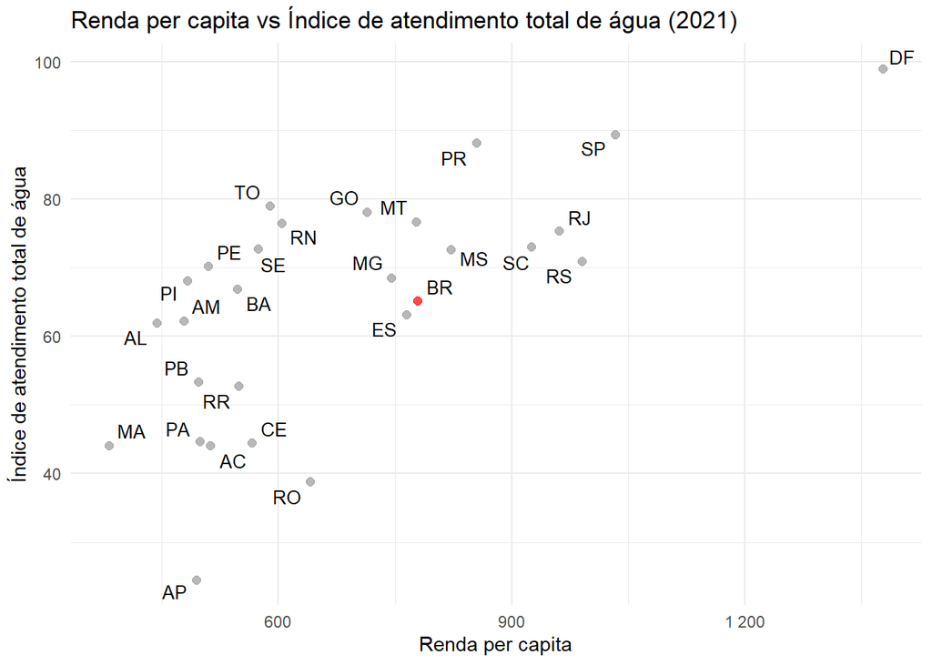

```r
df <- base_2020   # ou: df <- base_2021

#Auxílio do ChatGPT para formulação de todos os gráficos
plot_df <- df %>%
  select(sigla_uf, renda_per_capita, indice_atendimento_total_agua) %>%
  filter(!is.na(sigla_uf), !is.na(renda_per_capita), !is.na(indice_atendimento_total_agua)) %>%
  mutate(is_br = sigla_uf == "BR")

ggplot(plot_df, aes(x = renda_per_capita, y = indice_atendimento_total_agua)) +
  # todos os pontos com o MESMO tamanho; BR apenas com cor diferente
  geom_point(aes(color = is_br), alpha = 0.7, size = 2) +
  scale_color_manual(values = c(`FALSE` = "grey60", `TRUE` = "red"), guide = "none") +
  # rótulos das UFs (opcional)
  geom_text_repel(aes(label = sigla_uf), size = 3.5, max.overlaps = Inf) +
  scale_x_continuous(labels = label_number()) +
  labs(
    x = "Renda per capita",
    y = "Índice de atendimento total de água",
    title = "Renda per capita vs Índice de atendimento total de água (2021)"
  ) +
  theme_minimal()
```

Como o gráfico indica, os estados com uma maior renda per capita, em geral, possuem um maior atendimento total de água. É possível notar que os estados em que o atendimento total de água é abaixo da média brasileira são estados que possuem uma renda per capita inferior a média nacional.

Gráfico 2

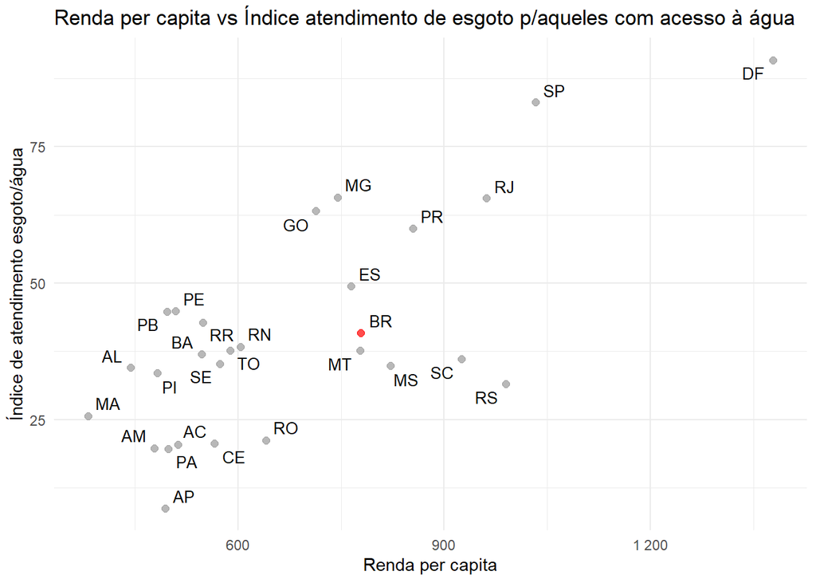

Renda per capita vs Índice atendimento de esgoto p/aqueles com acesso à água

```r
df <- base_2020   # ou: df <- base_2021

plot_df <- df %>%
  select(sigla_uf, renda_per_capita, indice_atendimento_esgoto_agua) %>%
  filter(!is.na(sigla_uf),
         !is.na(renda_per_capita),
         !is.na(indice_atendimento_esgoto_agua)) %>%
  mutate(is_br = sigla_uf == "BR")

ggplot(plot_df, aes(x = renda_per_capita, y = indice_atendimento_esgoto_agua)) +
  geom_point(aes(color = is_br), alpha = 0.7, size = 2) +
  scale_color_manual(values = c(`FALSE` = "grey60", `TRUE` = "red"), guide = "none") +
  geom_text_repel(aes(label = sigla_uf), size = 3.5, max.overlaps = Inf) +
  scale_x_continuous(labels = label_number()) +
  labs(
    x = "Renda per capita",
    y = "Índice de atendimento esgoto/água",
    title = "Renda per capita vs Índice atendimento de esgoto p/aqueles com acesso à água "
  ) +
  theme_minimal()
```

A partir deste gráfico podemos notar um alta discrepância entre aqueles que possuem acesso aos serviços de esgoto e de água com aqueles que apenas possuem atendimento total de água.

Aproximadamente, apenas 22% dos estados brasileiros possuem um atendimento de esgoto e água para um percentual maior que 50% da sua população. Simultaneamente, menos da metade da população brasileira possui acesso aos serviços de esgoto (coleta, transporte, tratamento e destinação final adequados do esgoto).

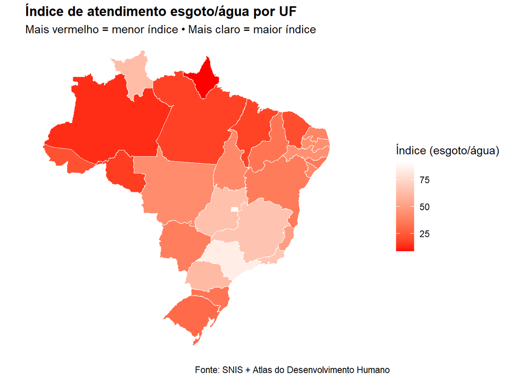

Índice de atendimento esgoto/água por UF

```r
df <- base_2021

# 1) Tabela por UF
map_dat <- df %>%
  filter(sigla_uf != "BR") %>%
  group_by(sigla_uf) %>%
  summarise(indice_atendimento_esgoto_agua = mean(indice_atendimento_esgoto_agua, na.rm = TRUE),
            .groups = "drop")


ufs <- geobr::read_state(code_state = "all", year = 2020, simplified = TRUE)

# 2) Join por sigla (geobr usa 'abbrev_state')
map_sf <- ufs %>%
  left_join(map_dat, by = c("abbrev_state" = "sigla_uf"))

# 3) Mapa
ggplot(map_sf) +
  geom_sf(aes(fill = indice_atendimento_esgoto_agua), color = "white", linewidth = 0.2) +
  scale_fill_gradient(
    low = "red", high = "white", na.value = "grey90",
    name = "Índice (esgoto/água)"
  ) +
  labs(
    title = "Índice de atendimento esgoto/água por UF",
    subtitle = "Mais vermelho = menor índice • Mais claro = maior índice",
    caption = "Fonte: SNIS + Atlas do Desenvolvimento Humano"
  ) +
  theme_void() +
  theme(
    plot.title = element_text(face = "bold"),
    legend.position = "right"
  )
```

Neste último gráfico é possível notar uma maior concetração de estados no norte/nordeste com baixo índice de atendimento total de esgoto referido aos estados atendidos com água. Ao passo que no sudeste estão localizados os estados com o maior índice. Através do gráfico vemos a desigualdade no nível de serviço de esgoto entre as diversas regiões do país.